# tuto_R

# Tutoriaux R

**SHS - Psychologie sociale**

## 1. Setting up markdown file

### Markdown options und chunks

> Ce premier chunk s’insère avec la commande : alt + cmd + i. A l’intérieur, nous pouvons y mette du code qui sera compilé lorsque nous ‘tricoterons’ ou ‘knit’ notre markdown. Pour le compiler avant : soit on appuie sur la flèche ferte, soit on selectionne le code voulu et on appuie sur cmd et enter.

### Ecrire dans Markdown

On peut soit écrire dans le markdown directement. Comme à l’instant.

> Ou alors insérer une boîte de texte à l’aide du symbole >

La mise en page des markdown suit le langage LateX la plupart du temps. Si vous avez des questions de mise en page veuillez vous référez au cheat sheet suivant https://rstudio.com/resources/cheatsheets/ (aussi sur moodle sous la séance plénière du 17.03.21)

Les outils de mise en page les plus souvent utilisés sont : * *italic* pour de l’italic * **bold** pour bold *
$$E = MC{2}$$
pour une equation en bloc ou * $\alpha = \beta$ pour equation en ligne * Les hashtag signifie les niveau de titre # = titre de niveau 1, ## pour niveau 2, etc. * pour ajouter une image $![légende]("../dossier/lien vers l'image en question")$ - sous rubrique * les note en bas de page[^1] - [^1]: Sont fait comme ceci

### les packages le plus souvent utilisés

```r
#Markdown packages
library(tidyverse)
library(tinytex)
library(rticles)
library(xaringan)
library(sjPlot)
library(lattice)
library(latticeExtra)
library(rmdformats)
library(see)
library(plm)

#Visualisation
library(ggplot2)
library(ggthemes)
library(gmodels)
library(kableExtra)
library(rockchalk)

#Base stats packages
library(plotrix)
library(Rmisc)
library(psych)
library(sjmisc)
library(nortest)
library(pastecs)
library(car)
#library(Rcmdr)
source("../functions/outlierKD.R")
library(effects)
library(lm.beta)

# ez anova tools
library(ez)
library(stats)
library(DescTools)

#MLM packages
library(nlme) # linear models with intra participant correlations (repeated measures)
library(haven)
library(lme4)
library(lmerTest)
```

### Concvention du cours et élément de base

- dans un chunck ‘<-’ permet de créer un objet (avec le nom de gauche) partir de ce qu’il y a à droite.
- les objets créés sont suivis de .type d’object. Par exemple, pour des données (.dat)

## 2.Data

### Loading data

Les données doivent être nettoyées avant d’être utilisée. Nous allons voir les commandes pour importer des données dans votre Markdown

1. Enregistrer vos fichiers de données .csv dans le dossier ‘data’ du projet
2. Les importer en utilisant le chunk suivant :

```r
# Data set pas encore nettoyé
messy.dat <- read_csv("../data/looks_messy.csv")

# pour inspecter les premières lignes
head(messy.dat)
```

```
# A tibble: 6 × 11
  id    strategy att_h…¹ av_high ug_high att_s…² av_some ug_some att_n…³ av_none
  <chr> <chr>      <dbl>   <dbl>   <dbl>   <dbl>   <dbl>   <dbl>   <dbl>   <dbl>
1 ip58d Hard to…      86      84      67      88      69      50      97      48
2 mx86n Hard to…      91      83      53      83      74      48      86      50
3 wv72f Hard to…      89      88      48      99      70      48      90      45
4 tn34w Hard to…      89      69      58      86      77      40      87      47
5 tb10h Hard to…      80      81      57      88      71      50      82      50
6 re43s Hard to…      80      84      51      96      63      42      92      48
# … with 1 more variable: ug_none <dbl>, and abbreviated variable names
#   ¹att_high, ²att_some, ³att_none
```

3. Si vos données sont ‘tidy’ et wide alors on obtient

```r
# Data set 'tidy'
tidy.dat <- read_csv("../data/looks_tidy.csv")
head(tidy.dat)
```

```
# A tibble: 6 × 5
  id    strategy    attractiveness charisma           rating
  <chr> <chr>       <chr>          <chr>               <dbl>
1 ip58d Hard to get Attractive     Highly charismatic     86
2 mx86n Hard to get Attractive     Highly charismatic     91
3 wv72f Hard to get Attractive     Highly charismatic     89
4 tn34w Hard to get Attractive     Highly charismatic     89
5 tb10h Hard to get Attractive     Highly charismatic     80
6 re43s Hard to get Attractive     Highly charismatic     80
```

```r
tail(tidy.dat)
```

```
# A tibble: 6 × 5
  id    strategy attractiveness charisma rating
  <chr> <chr>    <chr>          <chr>     <dbl>
1 wn86h Normal   Ugly           Dullard      48
2 vv09l Normal   Ugly           Dullard      40
3 lh16n Normal   Ugly           Dullard      47
4 qg19w Normal   Ugly           Dullard      46
5 rt58g Normal   Ugly           Dullard      45
6 yw31p Normal   Ugly           Dullard      47
```

## 3. Describing the data

### Decrire les données avec des chiffres

#### load the Data

Pour décrire les données nous allons utiliser la fonction describe du package {psych} * Premièrement importons les données de l’exercice.

```r
tuto.dat <- read_csv("../data/tuto_data.csv")
```

- Puis on decrit les données

```r
#Pour le dataset entier
describe(tuto.dat)
```

```
               vars  n  mean    sd median trimmed   mad min max range skew
id                1 80 40.50 23.24   40.5   40.50 29.65   1  80    79 0.00
age               2 80 15.62  1.27   15.5   15.53  0.74  14  18     4 0.46
sex*              3 80  1.50  0.50    1.5    1.50  0.74   1   2     1 0.00
condition_exp*    4 80  1.50  0.50    1.5    1.50  0.74   1   2     1 0.00
hi_salary         5 80  4.47  1.84    4.0    4.31  1.48   1  10     9 0.90
               kurtosis   se
id                -1.25 2.60
age               -0.74 0.14
sex*              -2.02 0.06
condition_exp*    -2.02 0.06
hi_salary          0.75 0.21
 [ reached 'max' / getOption("max.print") -- omitted 10 rows ]
```

```r
#Pour une partie
describe(tuto.dat$hi_salary)
```

```
   vars  n mean   sd median trimmed  mad min max range skew kurtosis   se
X1    1 80 4.47 1.84      4    4.31 1.48   1  10     9  0.9     0.75 0.21
```

```r
#En utilisant une formule
test.desc <- aggregate(formula = hi_salary ~ sex, data =tuto.dat, FUN = describe) %>% as.data.frame()
tab_df(test.desc)
```

| sex | hi_salary.vars | hi_salary.n | hi_salary.mean | hi_salary.sd | hi_salary.median | hi_salary.trimmed | hi_salary.mad | hi_salary.min | hi_salary.max | hi_salary.range | hi_salary.skew | hi_salary.kurtosis | hi_salary.se |
| --- | --- | --- | --- | --- | --- | --- | --- | --- | --- | --- | --- | --- | --- |
| Female | 1 | 40 | 5.075 | 2.2000874108509 | 5 | 4.96875 | 2.2239 | 1 | 10 | 9 | 0.442539167403605 | -0.483842223594694 | 0.347864363487575 |
| Male | 1 | 40 | 3.875 | 1.13651514141549 | 4 | 3.84375 | 1.4826 | 2 | 6 | 4 | 0.237887638601171 | -0.763550338189386 | 0.179698822107065 |

```r
# Pour l'erreur standard
std.error(tuto.dat$hi_salary)
```

```
[1] 0.2059057
```

- Nous pouvons aussi créer un tableau de descriptives à partir de certains groupes en combinant certaines fonctions

```r
# Précision des facteurs : Sous group_by suivi de la base de données et du ou des facteurs, la précision des facteurs permet d’obtenir nos indices statistiques en fonction de leurs modalités :

## Précision des statistiques et de la variable quantitative : Sous summarise suivi des fonctions désirées, en l’occurrence le nombre d’observations (n), la moyenne (mean) et l’écart-type (sd) de la variable quantitative. Les noms Nombre, Moyenne et EcartType sont les noms que vous souhaitez attribuer aux colonnes pour la fonction désirée et peuvent être modifiés selon besoins
group_by(tuto.dat, sex, wants_child) %>%
  dplyr::summarise(
    Nombre = n(),
    Mediane = median(hi_salary, na.rm = TRUE),
    EcartIQ = IQR(hi_salary, na.rm = TRUE),
    Moyenne = mean(hi_salary, na.rm = TRUE)
  )
```

```
# A tibble: 18 × 6
# Groups:   sex [2]
   sex    wants_child Nombre Mediane EcartIQ Moyenne
   <chr>        <dbl>  <int>   <dbl>   <dbl>   <dbl>
 1 Female           1      3     4      0.5     4.33
 2 Female           2      4     2.5    1.5     2.5
 3 Female           3      2     3.5    0.5     3.5
 4 Female           4      2     6.5    0.5     6.5
 5 Female           6      6     5      2.25    5.67
 6 Female           7      6     6      0.75    5.83
 7 Female           8      6     5      3.5     5.17
 8 Female           9      8     6      3.25    6.12
 9 Female          10      3     4      1.5     3.67
10 Male             2      2     3      1       3
11 Male             3      4     4      2       4
12 Male             4     10     4      1       3.7
13 Male             5      8     5      1.5     4.5
14 Male             6      4     3      0.25    3.25
15 Male             7      9     4      2       4.11
16 Male             8      1     2      0       2
17 Male             9      1     4      0       4
18 Male            10      1     4      0       4
```

### Décrire des données avec des graphes (plots)

- Pour décrire nos données de manière visuelles nous avons le choix entre différents graphiques. Le plus souvent nous utiliseront des
  - histogrammes
  - boxplots
- Pour décrire des effets (vos résultats), nous utiliseront surtout :
  - des line charts
  - scatterplot avec des lignes de régression.
- Ne pas oublier de coder en tant que facteur les variables importantes (as.factor(data$la_variable))

Pour faire les différents graphiques nous utiliseront les packages “ggplot2” ainsi que “plotrix”. GGplot2 utilise un language basé un ‘couche’ appelés layers dans lesquels ont estime 7 paramètres importants:

- the holy 7 parameters
  - *data*
  - *geom_function* (what object is being plotted.. line, bar, etc…)
  - *mapping = aes*(thetics), some *stats* and *positions*
  - what *coordinate system* (often cartesian system x,y)
  - *facet_function*
- on peut toujours trouver les arguments en tapant ?geom_votregeomenquestion

#### Voici un example d’histogramme

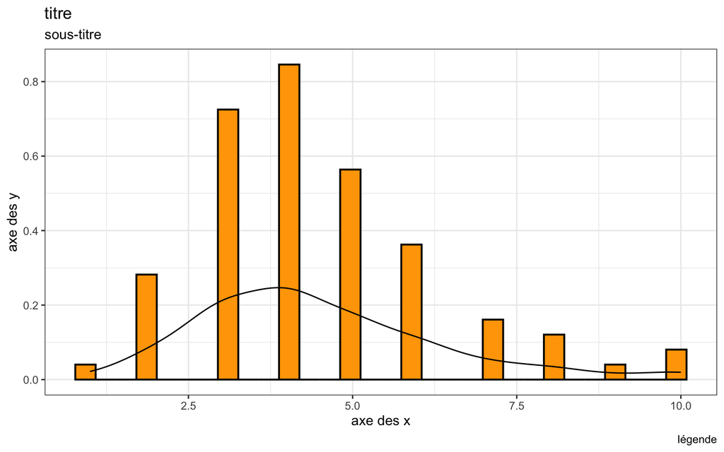

```r
hi_salary.histo <- ggplot(tuto.dat, aes(hi_salary)) # créer l'objet ainsi que insérer les data
hi_salary.histo + # + ajoute les layers
  geom_histogram(
    aes(y = stat(density)), size = 0.7,  # quel forme de graph (= geom_) et quel aesthetics va-t-on mapper ?
    alpha = 1, colour = "black", fill ="orange") + # quelques options du geom
  geom_density(size = 0.5) + # un autre pour la densité
  labs(x = "axe des x", y = "axe des y", title = "titre", subtitle = "sous-titre", caption = "légende")+ # les légendes
  theme_bw() # un theme pour faire joli
```

#### Un exemple de boxplot

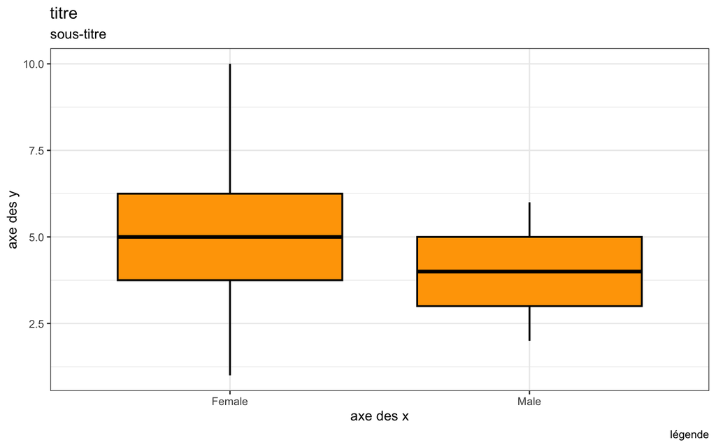

```r
hi_salary.boxplot <- ggplot(tuto.dat, aes(sex, hi_salary)) # créer l'objet ainsi que insérer les data
hi_salary.boxplot + # + ajoute les layers
  geom_boxplot(size = 0.7,  alpha = 1, colour = "black", fill ="orange") + # quelques options du geom
  labs(x = "axe des x", y = "axe des y", title = "titre", subtitle = "sous-titre", caption = "légende")+ # les légendes
  theme_bw() # un theme pour faire joli
```

#### Stats graphs

Parfois nous voulons faire un graph d’une interaction pour nos effets. Pour ce faire il faut créer un objet contenant les infos à ensuite donner au graphique.

S’il y a des NA on peut les enlever en les repérants avec la commande : object <- object[-c(ligneA, ligneB),]

- D’abord pour deux variables sans interactions

```r
# créer l'objet
df <- ddply(tuto.dat, c("condition_exp", "sex"), dplyr::summarize,
            Mean = mean(attractive, na.rm=T),
            SE   = std.error(attractive, na.rm=T))
df
```

```
  condition_exp    sex Mean        SE
1   Francophone Female 7.45 0.4070109
2   Francophone   Male 3.85 0.5538145
3  Germanophone Female 8.00 0.4167544
4  Germanophone   Male 5.10 0.3692097
```

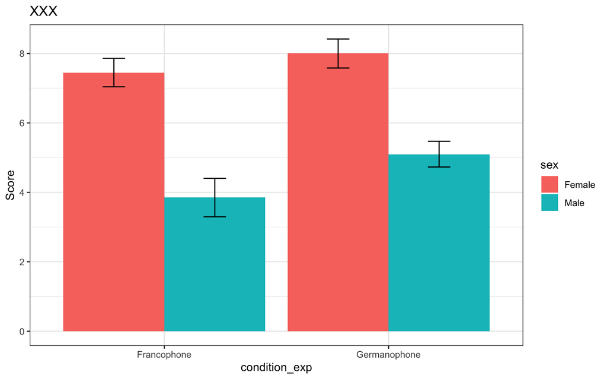

```r
attractive.bar <- ggplot(df, aes(x = condition_exp, y = Mean, fill = sex))
attractive.bar +
  geom_bar(stat = "identity", position = "dodge") +
  ggtitle("XXX") +
  ylab("Score") +
  geom_errorbar(aes(ymin = Mean-SE, ymax = Mean+SE), width = 0.2, position = position_dodge(0.9)) +
  theme_bw()
```

- Pour une interaction

```r
cond.sex.attractive <- ddply(tuto.dat, .(condition_exp, sex),  # créer l'objet
                     dplyr::summarise, val=mean(attractive, na.rm=T))
cond.sex.attractive # controler l'objet
```

```
  condition_exp    sex  val
1   Francophone Female 7.45
2   Francophone   Male 3.85
3  Germanophone Female 8.00
4  Germanophone   Male 5.10
```

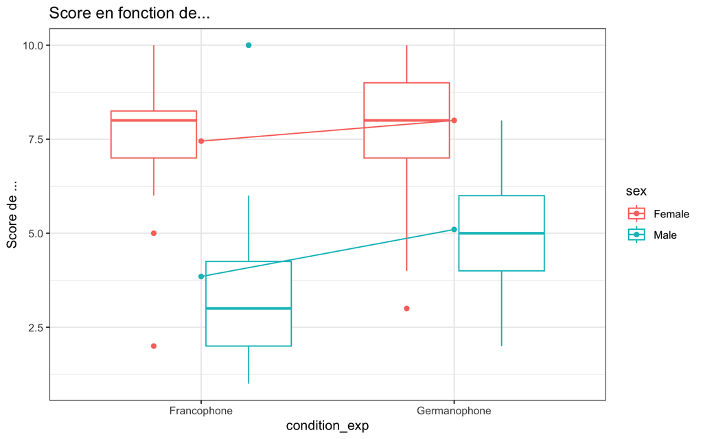

```r
interaction.plot <- ggplot(tuto.dat, aes(x=condition_exp, y=attractive, colour=sex))
interaction.plot +
  geom_boxplot() +
  geom_point(data = cond.sex.attractive, aes(y = val)) +
  geom_line(data = cond.sex.attractive, aes(y = val, group = sex)) +
  ggtitle("Score en fonction de...") + ylab("Score de ...") +
  theme_bw()
```

- exemple en scatterplot

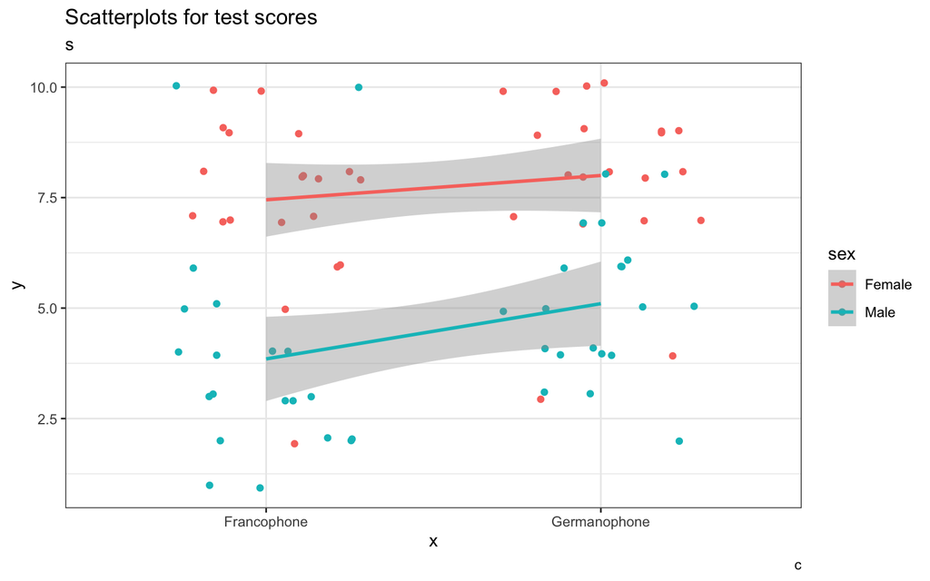

```r
example.plot <- ggplot(tuto.dat, aes(condition_exp, attractive, colour = sex)) +
  geom_point(position = position_jitter(width = 0.3, height = 0.1)) +
  geom_smooth(aes(group = sex),method = lm) +
  labs(
    title = "Scatterplots for test scores",
    subtitle = "s",
    caption = "c",
    x = "x",
    y = "y") +
  theme_bw()

example.plot
```

## 4. Assomptions

Il convient de contrôler un certain nombres d’assomptions avant de procéder aux analyses inférentielles. Celles-ci sont : - la normalité - les outliers - heteroscedasticité - sphéricité - linéarité

### Normalité

- La normalité peut-être controlée de manière visuelle
  - histogramme (devraient suivre une courbe normale)
  - boxplots (moyenne au milieu de la boite, moustache égales, pas d’outliers)
  - qqplot (devraient suivre la diagonale)

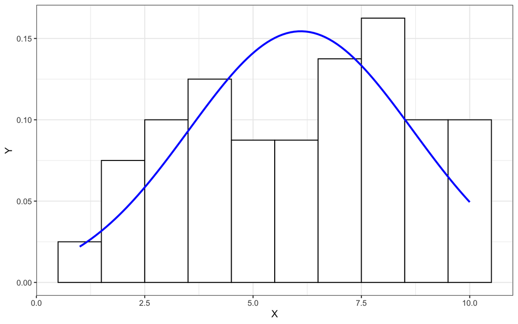

```r
norm.attractive <- ggplot(tuto.dat, aes(attractive))  +
  geom_histogram(aes(y = ..density..), fill = "white", colour = "black", binwidth = 1) +
  labs(
    x= "X",
    y = "Y") +
  stat_function(fun=dnorm, args=list(mean = mean(tuto.dat$attractive, na.rm = TRUE), sd = sd(tuto.dat$attractive, na.rm = TRUE)), colour = "blue", size=1) +
  theme_bw()

norm.attractive
```

```r
# voir section graphique
```

- Avec des chiffres
  - test de Liliefors
    - si significatif alors donnée non normales
    - si grand nombre de participant.e.s (N > 50) alors test trop puissant et sera trop souvent sign. -> observation
  - Skew
    - If the skewness is between -0.5 and 0.5, the data are fairly symmetrical
    - If the skewness is between -1 and – 0.5 or between 0.5 and 1, the data are moderately skewed
    - If the skewness is less than -1 or greater than 1, the data are highly skewed
  - Kurtosis
    - Should be between -1 and +1 (see excess kurtosis for an application to different sample sizes)

```r
# test normalité en fonction d'un groupe ici feminin
lillie.test(tuto.dat$attractive[tuto.dat$sex=="Female"])
```

```
    Lilliefors (Kolmogorov-Smirnov) normality test

data:  tuto.dat$attractive[tuto.dat$sex == "Female"]
D = 0.19675, p-value = 0.0004603
```

```r
# nombre de cas
length(tuto.dat$attractive[tuto.dat$sex=="Female"])
```

```
[1] 40
```

```r
lillie.test(tuto.dat$attractive[tuto.dat$sex=="Male"])
```

```
    Lilliefors (Kolmogorov-Smirnov) normality test

data:  tuto.dat$attractive[tuto.dat$sex == "Male"]
D = 0.16156, p-value = 0.01015
```

```r
length(tuto.dat$attractive[tuto.dat$sex=="Male"])
```

```
[1] 40
```

```r
# on en concluerait que notre distribution n'est pas normale
```

```r
# pour avoir plusieurs variables
round(stat.desc(tuto.dat[, c("attractive", "hi_salary")], basic = FALSE, norm = TRUE), digits = 3)
```

```
             attractive hi_salary
median            6.500     4.000
mean              6.100     4.475
SE.mean           0.289     0.206
CI.mean.0.95      0.575     0.410
var               6.673     3.392
std.dev           2.583     1.842
coef.var          0.423     0.412
skewness         -0.183     0.904
skew.2SE         -0.340     1.680
kurtosis         -1.152     0.752
kurt.2SE         -1.083     0.707
normtest.W        0.943     0.921
normtest.p        0.001     0.000
```

```r
# par groupe
by(tuto.dat[, c("attractive", "hi_salary")], tuto.dat$sex, describe) %>% tab_dfs(titles = c("female", "male"))
```

female

| vars | n | mean | sd | median | trimmed | mad | min | max | range | skew | kurtosis | se |
| --- | --- | --- | --- | --- | --- | --- | --- | --- | --- | --- | --- | --- |
| 1 | 40 | 7.72 | 1.84 | 8 | 7.97 | 1.48 | 2 | 10 | 8 | -1.17 | 1.42 | 0.29 |
| 2 | 40 | 5.08 | 2.20 | 5 | 4.97 | 2.22 | 1 | 10 | 9 | 0.44 | -0.48 | 0.35 |

male

| vars | n | mean | sd | median | trimmed | mad | min | max | range | skew | kurtosis | se |
| --- | --- | --- | --- | --- | --- | --- | --- | --- | --- | --- | --- | --- |
| 1 | 40 | 4.47 | 2.17 | 4 | 4.28 | 1.48 | 1 | 10 | 9 | 0.71 | 0.14 | 0.34 |
| 2 | 40 | 3.88 | 1.14 | 4 | 3.84 | 1.48 | 2 | 6 | 4 | 0.24 | -0.76 | 0.18 |

### Outliers

- On peut contrôler les outliers de manières visuelles avec les boxplots
- Pour obtenir des infos plus spécifiques on peut utiliser :

```r
boxplot(tuto.dat$hi_salary)$out #Valeurs des VE
```

```
[1]  9 10 10
```

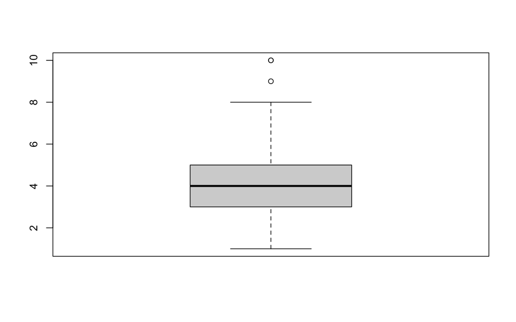

```
[1] 3
```

```r
length(boxplot(tuto.dat$hi_salary)$out) # nombre de VE
```

- Il convient aussi d’utiliser la fonction (qui n’est malheureusement pas dans un package) outliersKD que l’on peut *source* (comme un library pour un script qui résume une fonction écrite). Celle ci se trouve dans le dossier ‘functions’ et il est sourcer au début avec les autres package.
- Cette fonction permet
  - de voir la valeur de notre moyenne avec et sans
  - ainsi que les boxplots avec et sans
  - l’histogramme de la variable avec et sans

```r
#taper dans la console outlierKD(data, la_variable_d'intéret)
# puis écrire oui ou non pour valider le choix. Attention ! ces cas seront remplacé par des NA
```

### Homogénéité des variance

- Il faut que la variance de chaque variable soient égaux afin de pouvoir être comparable.
  - on utilise soit le test de Lavene (qui doit être non significatif) mais celui ci l’est trop souvent alors on utilise aussi
  - Hartley’s F max = le ratio des variances (la valeur finale doit être en dessous de la valeur critique du tableau)
    - le plus large / le plus petit (et le n-1 est le groupe avec le plus grand N)

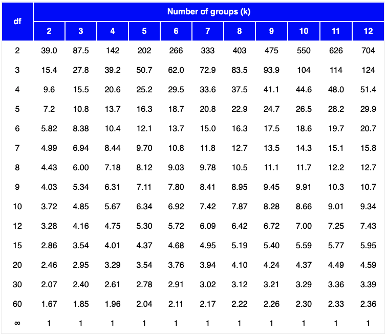

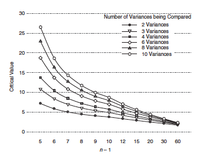

```r
# Levene test
leveneTest(tuto.dat$attractive, tuto.dat$condition_exp, center = mean)  %>%
  knitr::kable(., digits = 2, format = "html", align = 'c') %>%
  kableExtra::kable_styling(., bootstrap_options = "striped")
```

|  | Df | F value | Pr(>F) |
| --- | --- | --- | --- |
| group | 1 | 3.67 | 0.06 |
|  | 78 | NA | NA |

```r
# Hartley's Fmax
ff <- tuto.dat %>% group_by(condition_exp) %>%
  dplyr::summarise(
    Df = n()-1,
    Variance = var(attractive, na.rm = T))
ff$Variance[1] / ff$Variance[2]
```

```
[1] 1.530956
```

### Heteroscedasticité

- Il convient de contrôler que la variance des résiduels soient égales à chaque degré de nos prédicteurs; qu’ils soient donc homoscedastique. Sans quoi nos conditions/variables prédictrice continues ne serait pas comparables.
  - ceci se teste par inspection visuelle:

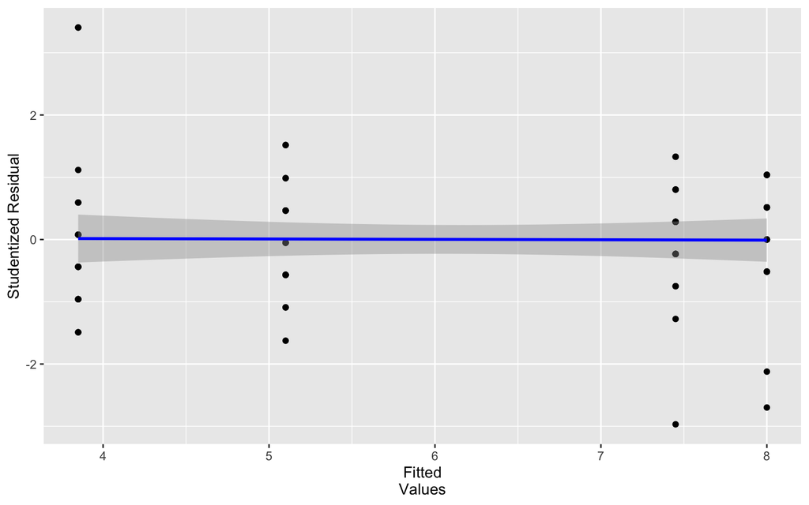

```r
# pour un model simple qui cherche à prédire l'importance de l'attractivité en fonction de la région langagière et du genre
attractive.mod <- lm(attractive ~ sex + condition_exp + sex*condition_exp, data = tuto.dat, na.action = na.omit)

#fitted values pour plot et std. and studentised residuals dans nos données
tuto.dat$fitted <- attractive.mod$fitted.values
tuto.dat$standardized.residuals<- rstandard(attractive.mod)
tuto.dat$studentized.residuals<-rstudent(attractive.mod)

# plot des fitted values against std. residuals
scatter.resid <- ggplot(tuto.dat, aes(fitted, studentized.residuals))
scatter.resid + geom_point() + geom_smooth(method = "lm", colour = "Blue")+ labs(x = "Fitted
Values", y = "Studentized Residual")
```

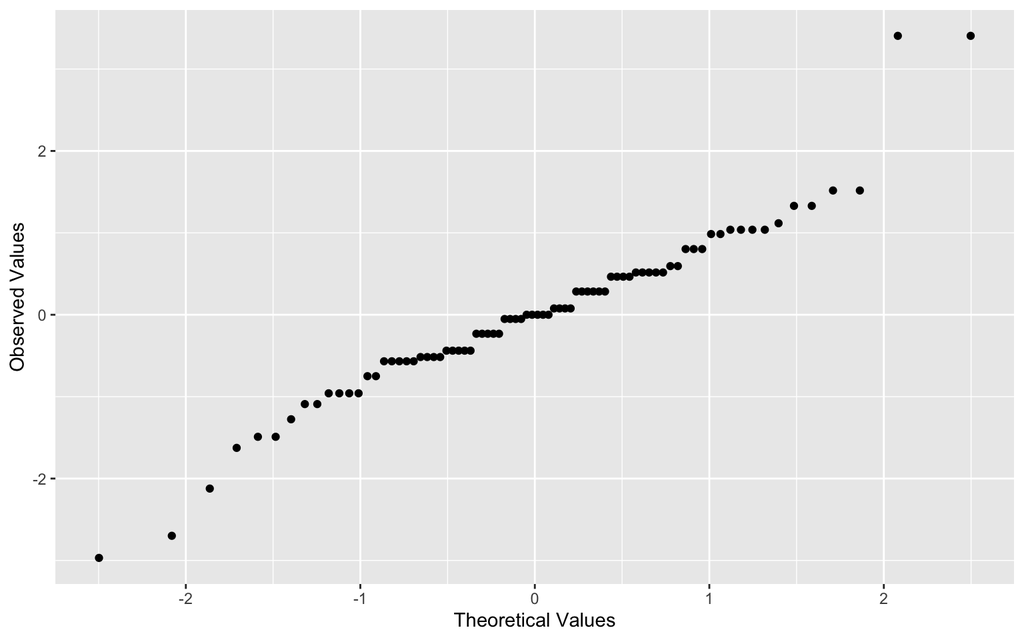

```r
# qqplot des residuals
qqplot.resid <- ggplot(tuto.dat, aes(sample=tuto.dat$studentized.residuals)) + stat_qq() + labs(x =
"Theoretical Values", y = "Observed Values")
qqplot.resid
```

### independence (of errors)

- On peut contrôler ceci avec un test de Durbin-Watson test
  - idéalement à 2 (pas <1 et > 3)

```r
dwt(attractive.mod)
```

```
 lag Autocorrelation D-W Statistic p-value
   1       0.2559536      1.307055   0.002
 Alternative hypothesis: rho != 0
```

### mutlicolinearité

- Prédicteurs ne doivent pas être parfaitement corrélés.
- To check for multicollinearity, use the VIF values. If these values are *less than 10* then that indicates there probably isn’t cause for concern. If you take the average of VIF values, and this average is not substantially greater than 1, then that also indicates that there’s no cause for concern.

```r
vif(attractive.mod)
```

```
              sex     condition_exp sex:condition_exp
                2                 2                 3
```

```r
1/vif(attractive.mod)
```

```
              sex     condition_exp sex:condition_exp
        0.5000000         0.5000000         0.3333333
```

```r
mean(vif(attractive.mod))
```

```
[1] 2.333333
```

### Linéarité

```r
## plot(model.1, which = 1) # residuals vs fitted une fois le modèle écrit (cf. 5 )
```

## 5. Linear regression

### Writting/running models

```r
factor(tuto.dat$sex)
```

```
 [1] Female Female Female Female Female Female Female Female Female Female
[11] Female Female Female Female Female Female Female Female Female Female
[21] Female Female Female Female Female Female Female Female Female Female
[31] Female Female Female Female Female Female Female Female Female Female
[41] Male   Male   Male   Male   Male   Male   Male   Male   Male   Male
[51] Male   Male   Male   Male   Male   Male   Male   Male   Male   Male
[61] Male   Male   Male   Male   Male   Male   Male   Male   Male   Male
[71] Male   Male   Male   Male   Male
 [ reached getOption("max.print") -- omitted 5 entries ]
Levels: Female Male
```

Le but de a régression linéaire permet de savoir si une variable quantitative (régression simple) ou plusieurs variables quantitatives (régression multiple), appelées prédicteurs (ou VI quantitatives), sont passible(s) de prédire les valeurs d’une autre variable quantitative appelée critère (ou VD).

- General form : newModel<-lm(outcome ~ predictor(s), data = dataFrame, na.action = an action))

```r
model.0 <- lm(n_partners ~ sex, data = tuto.dat, na.action = na.omit)
summary (model.0)
```

```
Call:
lm(formula = n_partners ~ sex, data = tuto.dat, na.action = na.omit)

Residuals:
   Min     1Q Median     3Q    Max
  -9.4   -3.4    0.4    2.6   11.6

Coefficients:
            Estimate Std. Error t value Pr(>|t|)
(Intercept)   4.6000     0.6941   6.627 4.00e-09 ***
sexMale       5.8000     0.9816   5.909 8.57e-08 ***
---
Signif. codes:  0 '***' 0.001 '**' 0.01 '*' 0.05 '.' 0.1 ' ' 1

Residual standard error: 4.39 on 78 degrees of freedom
Multiple R-squared:  0.3092,    Adjusted R-squared:  0.3003
F-statistic: 34.91 on 1 and 78 DF,  p-value: 8.569e-08
```

Pour des coefficients de régression standardisés on emploie la même formule mais avec lm.beta

```r
lm.beta(model.0)
```

```
Call:
lm(formula = n_partners ~ sex, data = tuto.dat, na.action = na.omit)

Standardized Coefficients::
(Intercept)     sexMale
  0.0000000   0.5560496
```

Pour visualiser rapidement les effets on peut employer plot(allEffects(mon_modele.version))

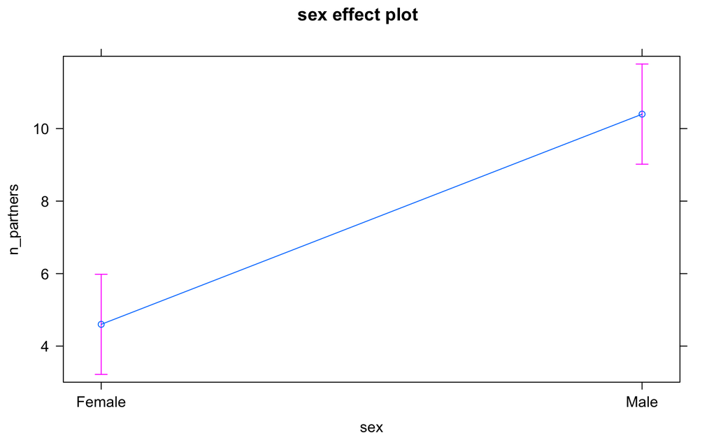

```r
plot(allEffects(model.0))
```

```r
# ici il n'y en a qu'un
```

Pour n’avoir que les coefficients (à noter dans notre rapport) :

```r
coef(model.0)
```

```
(Intercept)     sexMale
        4.6         5.8
```

### ajouter des prédicteurs

Souvent nous voulons savoir l’effet d’un prédicteur numérique sur notre VD. Il s’agit alors de l’ajouter dans le modèle de la même manière.

```r
model.1 <- lm(n_partners ~ sex + hi_salary, data = tuto.dat, na.action = na.omit)
summary(model.1)
```

```
Call:
lm(formula = n_partners ~ sex + hi_salary, data = tuto.dat, na.action = na.omit)

Residuals:
    Min      1Q  Median      3Q     Max
-9.0858 -3.3475  0.1584  2.7047 11.9142

Coefficients:
            Estimate Std. Error t value Pr(>|t|)
(Intercept)   6.0176     1.5995   3.762 0.000327 ***
sexMale       5.4648     1.0393   5.258 1.26e-06 ***
hi_salary    -0.2793     0.2839  -0.984 0.328313
---
Signif. codes:  0 '***' 0.001 '**' 0.01 '*' 0.05 '.' 0.1 ' ' 1

Residual standard error: 4.391 on 77 degrees of freedom
Multiple R-squared:  0.3178,    Adjusted R-squared:    0.3
F-statistic: 17.93 on 2 and 77 DF,  p-value: 4.04e-07
```

Nous pouvons les visualiser de la manière suivante :

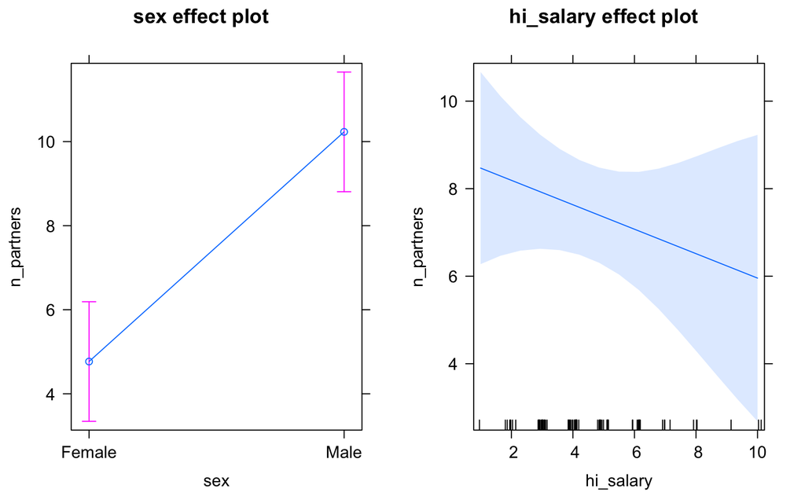

```r
# using allEffect
plot(allEffects(model.1))
```

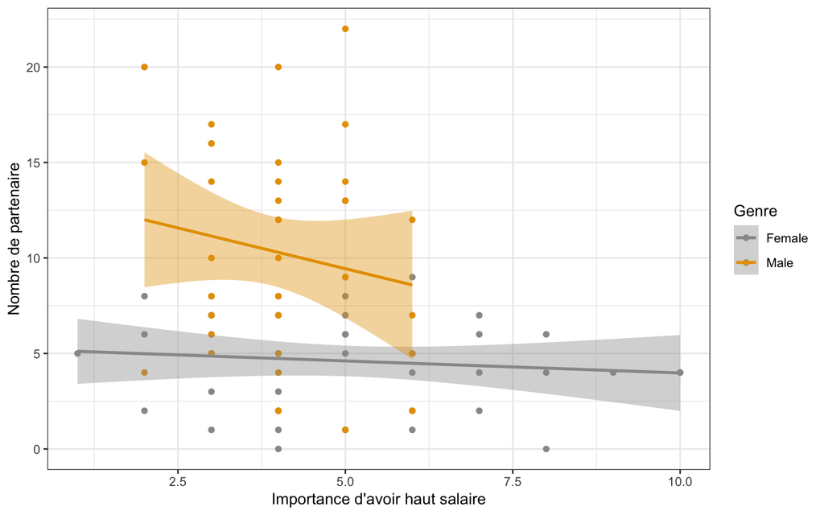

```r
# the nice way
ggplot(tuto.dat, aes(x=hi_salary, y=n_partners, fill=sex, color=sex)) +
        geom_point(size = 1.5) +
        labs(x = "Importance d'avoir haut salaire", y ="Nombre de partenaire", colour = "Genre") +
        scale_color_manual(values=c('#999999','#E69F00')) +
        scale_fill_manual(values =c('#999999','#E69F00')) +
        guides(fill = F) +
        geom_smooth(method=lm) +
        theme_bw()
```

### Ajouter terme d’interaction (moderation)

Une variable modératrice (ou modérateur) est une variable qui altère la force, et possiblement la direction, du lien entre un prédicteur et un critère. Ainsi, l’effet du prédicteur sur le critère dépend également des niveaux de cette variable modératrice. La modération est l’équivalent de l’effet d’interaction de l’ANOVA pour la régression.

Nous voyons ici sur le plot que nos lignes de régression ne sont pas parrallèle, il se pourait donc qu’il y ait un effet d’interaction. Il s’agit alors de l’ajouter dans votre modèle comme un prédicteur à part entière.

```r
model.2 <- lm(n_partners ~ sex + hi_salary + sex*hi_salary, data = tuto.dat, na.action = na.omit)
summary(model.2)
```

```
Call:
lm(formula = n_partners ~ sex + hi_salary + sex * hi_salary,
    data = tuto.dat, na.action = na.omit)

Residuals:
    Min      1Q  Median      3Q     Max
-8.4397 -3.1835  0.0797  2.8897 12.5603

Coefficients:
                  Estimate Std. Error t value Pr(>|t|)
(Intercept)         5.2398     1.7631   2.972  0.00396 **
sexMale             8.4679     3.0545   2.772  0.00700 **
hi_salary          -0.1261     0.3194  -0.395  0.69414
sexMale:hi_salary  -0.7275     0.6959  -1.045  0.29913
---
Signif. codes:  0 '***' 0.001 '**' 0.01 '*' 0.05 '.' 0.1 ' ' 1

Residual standard error: 4.388 on 76 degrees of freedom
Multiple R-squared:  0.3274,    Adjusted R-squared:  0.3009
F-statistic: 12.33 on 3 and 76 DF,  p-value: 1.172e-06
```

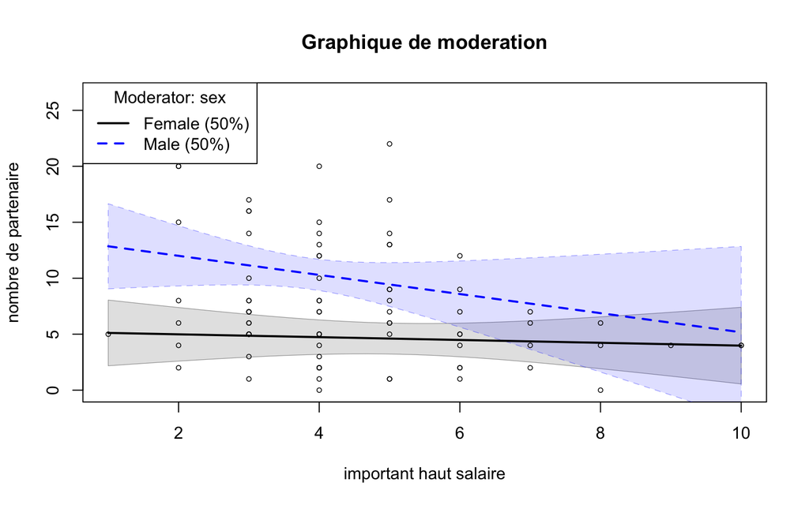

```r
plotSlopes(model.2, plotx="hi_salary", modx="sex",
           interval="confidence", main="Graphique de moderation",
           xlab="important haut salaire", ylab="nombre de partenaire")
```

Ici la paramètre d’interaction n’est pas significatif, nous n’avons donc qu’un seul effet de genre à reporter.

### Comparer des modèle

On peut comparer des modèles qui sont nesté avec la fonction anova()

```r
anova(model.1, model.2)
```

```
Analysis of Variance Table

Model 1: n_partners ~ sex + hi_salary
Model 2: n_partners ~ sex + hi_salary + sex * hi_salary
  Res.Df    RSS Df Sum of Sq     F Pr(>F)
1     77 1484.5
2     76 1463.5  1    21.047 1.093 0.2991
```

Ici l’output nous montre que notre F score ne s’est pas significativement améliorer. En d’autre terme, l’inclusion de cette variable dans notre modèle n’a pas su mieux répartir la variance de celui-ci.

### Mesure répétées - quick walkthrough

```r
# nouvelles données longitudinales
longLoss_ratio <- read_csv("../data/longLoss_ef.csv")
longLoss_ratio <- longLoss_ratio %>% subset(select = -c(lickert_score))

longLoss_ratio$PE_measure <-factor(longLoss_ratio$PE_measure)
```

```r
model.repeated <- ezANOVA(data = longLoss_ratio,
                         dv = .(ratio_OT),
                         wid = .(participant_ID),
                         within = .(PE_measure),
                         detailed = T, type = 3)
model.repeated
```

```
$ANOVA
       Effect DFn DFd       SSn      SSd         F            p p<.05       ges
1 (Intercept)   1 108 1809.7539 874.9763 223.38139 4.733029e-28     * 0.5431412
2  PE_measure   2 216  251.7034 647.2833  41.99702 3.915991e-16     * 0.1418876

$`Mauchly's Test for Sphericity`
      Effect         W         p p<.05
2 PE_measure 0.9602378 0.1140949

$`Sphericity Corrections`
      Effect       GGe        p[GG] p[GG]<.05       HFe        p[HF] p[HF]<.05
2 PE_measure 0.9617584 1.304583e-15         * 0.9788377 7.621337e-16         *
```

```r
# recreating model sans facteurs intersujets pour voir ou sont les différences
model.repeated.post <- aov(ratio_OT ~ PE_measure,
                         data=longLoss_ratio)

# post hoc tests for all variables (other specifiy under 'which' = "")
PostHocTest(model.repeated.post, which=NULL,
            method="hsd", conf.level=.95)
```

```
  Posthoc multiple comparisons of means : Tukey HSD
    95% family-wise confidence level

$PE_measure
                                                              diff      lwr.ci
population opportunity self-nature opportunity self     -1.3419179 -2.03323747
ressources opportunity self-nature opportunity self      0.7827436  0.09142395
ressources opportunity self-population opportunity self  2.1246614  1.43334182
                                                            upr.ci    pval
population opportunity self-nature opportunity self     -0.6505983 2.1e-05 ***
ressources opportunity self-nature opportunity self      1.4740632  0.0219 *
ressources opportunity self-population opportunity self  2.8159810 1.1e-11 ***

---
Signif. codes:  0 '***' 0.001 '**' 0.01 '*' 0.05 '.' 0.1 ' ' 1
```

```r
# summary
summary(lm(model.repeated.post))
```

```
Call:
lm(formula = model.repeated.post)

Residuals:
    Min      1Q  Median      3Q     Max
-3.1788 -1.6550 -0.5970  0.9611  5.8030

Coefficients:
                                      Estimate Std. Error t value Pr(>|t|)
(Intercept)                             2.5389     0.2076  12.229  < 2e-16 ***
PE_measurepopulation opportunity self  -1.3419     0.2936  -4.570 6.93e-06 ***
PE_measureressources opportunity self   0.7827     0.2936   2.666  0.00806 **
---
Signif. codes:  0 '***' 0.001 '**' 0.01 '*' 0.05 '.' 0.1 ' ' 1

Residual standard error: 2.168 on 324 degrees of freedom
Multiple R-squared:  0.1419,    Adjusted R-squared:  0.1366
F-statistic: 26.79 on 2 and 324 DF,  p-value: 1.715e-11
```

et savoir comment les décrires en fonctions des variables selectionnées

```r
# getting descriptives by variable

ezStats(data = longLoss_ratio,
                         dv = .(ratio_OT),
                         wid = .(participant_ID),
                         within = .(PE_measure))
```

```
                   PE_measure   N     Mean       SD      FLSD
1     nature opportunity self 109 2.538925 2.414471 0.4621792
2 population opportunity self 109 1.197007 1.511559 0.4621792
3 ressources opportunity self 109 3.321669 2.445510 0.4621792
```

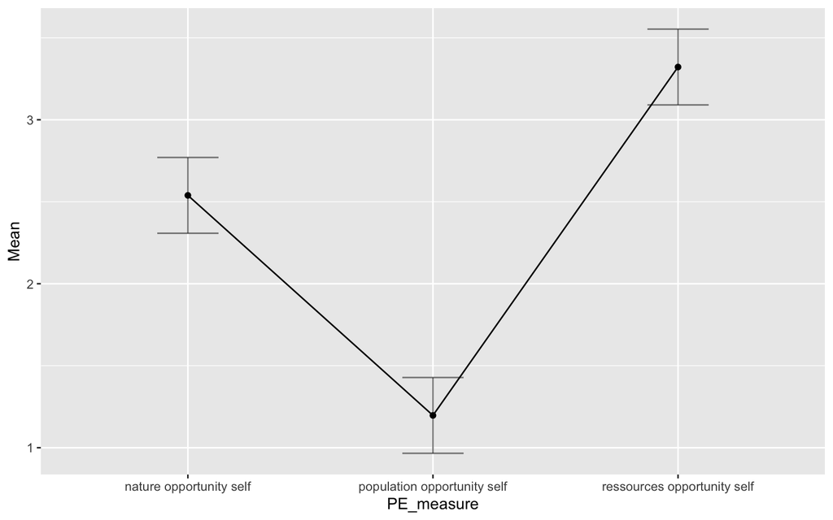

```r
ezPlot(data = longLoss_ratio,
       dv = .(ratio_OT),
       wid = .(participant_ID),
       within = .(PE_measure),
       x = .(PE_measure),
       do_lines = TRUE)
```

## 6. Fidélité

### Choisir ses variables

- Lorsque vous aurez différents items, il conviendra de voir si celles si corrèlent ensemble afin de savoir s’il est acceptable de toutes les garder dans votre quête de score final.
  - Ceci se fait avec l’alpha de Cronbach
- Tout d’abord, il convient de mesurer les items sur la base des facteurs théoriques latent. Par exemple, il se peut que vos items soient une moitié en lien avec les émotions et les autres avec les intentions comportementales. Il faut les séparer. On peut faire cela en créant des subsets.

```r
high_functionning <- tuto.dat[, c("hi_salary",  "fin_ed",   "ambitious",    "attractive")]
nice <- tuto.dat[, c("kind",    "humour", "wants_child",    "romantic", "creativity",   "honest")]
```

- attention s’il y a des valeurs à recoder, ceci peut-être fait directement ici (si pas encore fait au moment des nettoyage de données)

```r
# l'argument keys = c(1, 1, 1, -1) pour un objet à 4 items ou le dernier est à inverser
## directement dans la fonction suivante
```

- la fonction de fiabilité et psych::alpha()

```r
psych::alpha(high_functionning)
```

```
Reliability analysis
Call: psych::alpha(x = high_functionning)

  raw_alpha std.alpha G6(smc) average_r S/N   ase mean  sd median_r
      0.55      0.57    0.59      0.25 1.3 0.081  5.2 1.3     0.14

 lower alpha upper     95% confidence boundaries
0.39 0.55 0.71

 Reliability if an item is dropped:
           raw_alpha std.alpha G6(smc) average_r  S/N alpha se   var.r med.r
hi_salary       0.28      0.29    0.22      0.12 0.42    0.135 0.00068  0.12
fin_ed          0.42      0.42    0.35      0.20 0.73    0.105 0.02298  0.12
ambitious       0.61      0.65    0.64      0.38 1.86    0.080 0.06970  0.37
attractive      0.58      0.57    0.56      0.31 1.33    0.082 0.08937  0.15

 Item statistics
            n raw.r std.r r.cor r.drop mean  sd
hi_salary  80  0.79  0.81  0.81   0.59  4.5 1.8
fin_ed     80  0.68  0.73  0.67   0.42  5.0 1.8
ambitious  80  0.46  0.51  0.19   0.16  5.1 1.7
attractive 80  0.69  0.60  0.37   0.27  6.1 2.6

Non missing response frequency for each item
              1    2    3    4    5    6    7    8    9   10 miss
hi_salary  0.01 0.09 0.22 0.26 0.17 0.11 0.05 0.04 0.01 0.03    0
fin_ed     0.01 0.03 0.12 0.26 0.25 0.14 0.10 0.03 0.04 0.03    0
ambitious  0.00 0.04 0.17 0.16 0.21 0.20 0.14 0.05 0.01 0.01    0
attractive 0.03 0.07 0.10 0.12 0.09 0.09 0.14 0.16 0.10 0.10    0
```

```r
psych::alpha(nice)
```

```
Some items ( wants_child ) were negatively correlated with the total scale and
probably should be reversed.
To do this, run the function again with the 'check.keys=TRUE' option
```

```
Reliability analysis
Call: psych::alpha(x = nice)

  raw_alpha std.alpha G6(smc) average_r S/N   ase mean  sd median_r
      0.49      0.53    0.62      0.16 1.1 0.089  6.2 1.1     0.19

 lower alpha upper     95% confidence boundaries
0.32 0.49 0.67

 Reliability if an item is dropped:
            raw_alpha std.alpha G6(smc) average_r  S/N alpha se var.r med.r
kind             0.30      0.33    0.41      0.09 0.49    0.127 0.045  0.16
humour           0.39      0.44    0.53      0.14 0.79    0.108 0.071  0.18
wants_child      0.64      0.65    0.67      0.27 1.83    0.065 0.035  0.26
romantic         0.43      0.47    0.58      0.15 0.89    0.103 0.073  0.18
creativity       0.52      0.55    0.61      0.20 1.23    0.087 0.053  0.18
honest           0.31      0.36    0.45      0.10 0.57    0.123 0.059  0.19

 Item statistics
             n raw.r std.r  r.cor r.drop mean  sd
kind        80  0.73  0.75  0.765   0.54  6.5 1.9
humour      80  0.60  0.61  0.509   0.36  6.3 2.0
wants_child 80  0.26  0.21 -0.046  -0.10  5.8 2.4
romantic    80  0.56  0.57  0.408   0.29  6.2 2.1
creativity  80  0.42  0.42  0.254   0.11  5.0 2.2
honest      80  0.71  0.71  0.692   0.49  7.1 2.0

Non missing response frequency for each item
               1    2    3    4    5    6    7    8    9   10 miss
kind        0.00 0.00 0.03 0.10 0.22 0.24 0.12 0.09 0.09 0.11    0
humour      0.00 0.00 0.07 0.15 0.16 0.15 0.14 0.17 0.09 0.06    0
wants_child 0.04 0.07 0.07 0.15 0.10 0.12 0.19 0.09 0.11 0.05    0
romantic    0.01 0.03 0.05 0.14 0.17 0.11 0.22 0.11 0.09 0.06    0
creativity  0.04 0.06 0.15 0.21 0.20 0.09 0.10 0.06 0.05 0.04    0
honest      0.00 0.01 0.04 0.07 0.06 0.22 0.14 0.19 0.10 0.16    0
```

- Les choses à garder en tête
  - une bonne corrélation globale est de .8 (.7 acceptable, attention au dela de .9 les items sont identitiques)
    - ceci correspond aux (raw_apha et leur écart type std.alpha)
  - ensuite on a l’alpha global en fonction de si un ou l’autre item est enlevé
  - Puis on a la colonne r.drop qui nous indique la correlation d’un item avec le reste.
    - attention à ne pas en avoir en dessous de .3 !
  - le tableau non missing response frequency :
    - nous indique quel pourcentage de personnes ont répondu de la même manière au même item. Utile pour savoir si tout le monde répond identiquement alors probablement que cet item n’est pas très utile pour différencier vos participant.e.s.
  - Une fois les items enlevées, il s’agit de refaire l’analyse afin de vérifier les nouveaux coefficients.

## 7. Mediation analysis

### Running Hayes process

```r
source("../extras/process.R")
```

```
********************** PROCESS for R Version 4.1 **********************

           Written by Andrew F. Hayes, Ph.D.  www.afhayes.com
   Documentation available in Hayes (2022). www.guilford.com/p/hayes3


PROCESS is now ready for use.
Copyright 2022 by Andrew F. Hayes ALL RIGHTS RESERVED
Workshop schedule at http://haskayne.ucalgary.ca/CCRAM
```

- Hayes Process utilise le bootstrapping afin de mener à bien des modèles de médiation
  - technique à partir de laquelle la distribution d’échantillonnage d’une statistique est estimée en prenant des valeurs répétées (avec remplacement, i.e. que l’on peut reprendre plusieurs fois la même valeurs) de l’ensemble des données (donc, en traitant les données comme une population à partir de laquelle de plus petits échantillons sont prélevés).
  - La statistique d’intérêt (e.g., la moyenne ou le coefficient b) est calculée pour chaque échantillon, à partir duquel la distribution d’échantillonnage de la statistique est estimée.
  - L’erreur type de la statistique est estimée comme étant l’écart type de la distribution d’échantillonnage créée à partir des échantillons bootstrap. À partir de là, des intervalles de confiance et des tests de signification peuvent être calculés.
- Ce programme (~ package) n’accepte que les variables numériques
  - attention a recoder ses variables catégoriques (genre etc.)
- Suites d’étapes :
  - $Y_𝑖=𝑏 ̂_ 0+𝑏 ̂_1 𝑋_𝑖+𝜀_𝑖$
  - $M_𝑖=𝑏 ̂_ 0+𝑏 ̂_1 𝑋_𝑖+𝜀_𝑖$
  - $Y_𝑖=𝑏 ̂_ 0+𝑏 ̂_1 𝑋_𝑖+𝑏 ̂_2 𝑀_𝑖+𝜀_𝑖$
  - là où $b_1 𝑋_𝑖$ est plus petit que dans la première équation
- pour plus d’info visiter le site
  - http://www.regorz-statistik.de/en/mediation_process_for_r.html#testing

### example de modèle

- on désire savoir si, dans les données du cours, la perception du degré de la difficulté , prédite par l’habitude que les étudiant.e.s ont de lire ce genre de texte, est expliqué par l’appréciation de ce genre d’exercice.

```r
feedback_dat <- read.csv("../data/feedback_data_clean.csv")
process(feedback_dat,
        y = "questions_hard_1",
        x = "usual_1",
        m = "like_it_1",
        effsize =1, # que l'on veut l'output du calcul la taille d'effet
        stand =1, # que l'on désire les coefficient standardisés
        modelbt = 1, # all regression coefficient pour toutes les paths (chemins) sont bootstrapped
        boot = 10000, # le nombre de bootstrap que l'on veut faire
        seed = 654321, # set seed permet de repliquer les résultats avec le même point de départ
        total = 1, # 1 désigne que l'on désire l'output de l'effet total (= c path )
        model = 4) # désigne le modèle de médiation que l'on désire performer
```

```
********************** PROCESS for R Version 4.1 **********************

           Written by Andrew F. Hayes, Ph.D.  www.afhayes.com
   Documentation available in Hayes (2022). www.guilford.com/p/hayes3


Model : 4
    Y : questions_hard_1
    X : usual_1
    M : like_it_1

Sample size: 41

Custom seed: 654321


Outcome Variable: like_it_1

Model Summary:
          R      R-sq       MSE         F       df1       df2         p
     0.1566    0.0245    2.3206    0.9807    1.0000   39.0000    0.3281

Model:
             coeff        se         t         p      LLCI      ULCI
constant    3.5877    0.5449    6.5837    0.0000    2.4854    4.6899
usual_1     0.1777    0.1795    0.9903    0.3281   -0.1853    0.5407

Standardized coefficients:
            coeff
usual_1    0.1566

Outcome Variable: questions_hard_1

Model Summary:
          R      R-sq       MSE         F       df1       df2         p
     0.2506    0.0628    1.5760    1.2736    2.0000   38.0000    0.2915

Model:
              coeff        se         t         p      LLCI      ULCI
constant     5.4835    0.6525    8.4034    0.0000    4.1625    6.8045
```

[output cut: 211 more lines]

```
constant    3.5877    3.5734    0.6386    2.3162    4.7963
usual_1     0.1777    0.1859    0.1952   -0.1800    0.5719
----------
Outcome variable: questions_hard_1

              Coeff  BootMean    BootSE  BootLLCI  BootULCI
constant     5.4835    5.4485    0.7150    3.9125    6.6857
usual_1     -0.2379   -0.2303    0.1359   -0.5081    0.0343
like_it_1    0.0528    0.0565    0.1495   -0.2170    0.3722

******************** ANALYSIS NOTES AND ERRORS ************************

Level of confidence for all confidence intervals in output: 95

Number of bootstraps for percentile bootstrap confidence intervals: 10000
```

```r
#  si on veut ajouter des covariates on doit ajouter cov = "age" ou cov = c("age", "gender"), s'il y en a plusieurs
```